# An Analysis of Thrones

Eleanor McGrath & Brett Olson

2017-12-20

“When you play the game of thrones, you win or you die.”

If you’ve ever read or watched Game of Thrones you have probably asked yourself a few of these questions. Who will win the game of thrones? Who has the most power? Who is the most important character? Are these the same person? Is your favorite character going to die? Which one is better the books or the show? And probably many many more. Some of these questions have been answered, some we will have to wait for George R. R. Martin to enlighten us with and some are simply personal preference. Data analysis can be used to explore the content of the books and tv show and provide a broader understanding of what in the world is going on.

By analyzing the text of the five published books, tv show scripts and viewer compiled datasets, we can better understand the different characters and plot lines in this fictional world. The text of the books was extracted from their digital publications and converted into regular text files. The tv show scripts were downloaded from genius.com where they have been uploaded by various users who either found the scripts or transcribed the show itself. Finally character information was collected from A Wiki of Ice and Fire, the user generated wiki. This takes a quantitative approach to this data which can be augmented with more traditional literary analysis techniques.

### A Note on the Number of Books

Currently, the Song of Ice and Fire series has five books published out of the intended seven books. In several parts of this article it only references 4 books. This is because when George R. R. Martin was writing the books he had originally had the 4th and 5th books combined. However, the book ended up being too long and so it was split with both books occurring at roughly the same time but each following different storylines. In order to look at the series as a whole from a chronological standpoint the chapters of these two books needed to occur in chronological order. To remedy this I merged the two books together and reordered the chapters so that they were in chronological order while maintaining the general structure of the books. I used this reordering (link) which I thought would work the best for my purposes but there are many different ways to do this. The author goes more in depth on his specific reordering methodology in the blog post.

## Character Analysis

There are certain pre-existing methods of text analysis that can be used in fiction to conduct a data-driven analyses, such as sentiment analysis and term frequency. However, due to the unusual and highly complex structure of the books within this series these techniques had to be adapted. Within the five published books there are over 2100 characters mentioned and multiple plot lines occurring simultaneously in all across the fantasy world. With so much happening at any given time it can be difficult to parse out the overall patterns and individual storylines. One way to approach this is to try and focus in on the main characters and how their roles in the story are changing over time.

### Chapter Breakdown

The structure of the books facilitates this type of analysis because each chapter is told from the point of view of one of the main characters. This gives as idea of these different storylines and what kind of role characters are playing in the story at different times. I looked at how these chapters were broken up by character and by allegiance. Figure 1 depicts the number of chapters in each main character’s point of view for each book. This shows how important each character’s plot line is and how it changes over the course of the series. This works very well for some characters like Jon whose role you can see increasing over the course of the series or Eddard who is the central character in the first book but dies at the end of the book and is gone from the rest of the series. However, this ignores characters who are mentioned often and play important roles but have few or no POV chapters. This can be seen with Cersei who is important throughout the books but only has POV chapters in the 4th and 5th books.

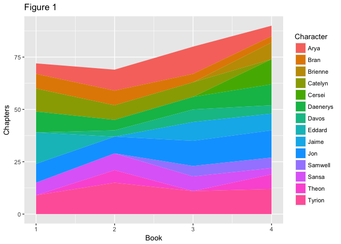

One way to address this problem while still exploring the overall trends of importance throughout the books is to look at groups of POV characters rather than individuals. Figure 2 shows the number of POV chapters that are focused on characters aligned with one of these 7 major groups. One of the main trends here is the switch from the first book which is heavily focused on the Starks to the later books which cover a much wider variety of storylines. The shift in power is also more evident here with the Starks trending downward while groups like the Lannisters and the Night’s Watch increase in importance. While this chart still only looks at POV characters, it provides important context which illuminates the overall trends of power more clearly.

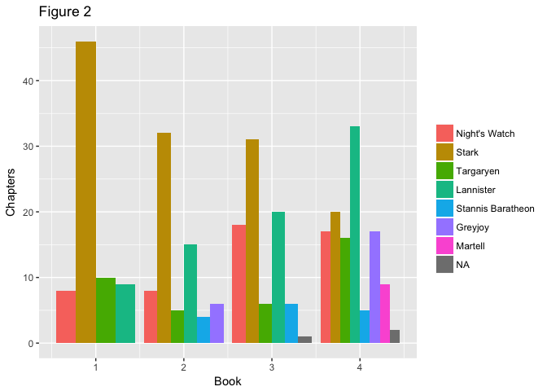

### Character Appearances

The two main issues so far have been only being able to look at POV characters and not showing when characters are mentioned or appear outside of their own chapters. To address this, I switched to looking for when these characters are mentioned throughout the text as depicted in figure 3. In addition to the POV characters I was already looking I added Khal Drogo and Robb to show how this would handle non-POV characters with different sized roles. This figure shows anytime a character either appears or is mentioned by someone else. This splits up the mentions by small section of text instead of chapters so it gives a more accurate idea when and often characters are being mentioned. The rows are also sorted based on if a character’s storyline is more heavily weighted to the beginning or the end of the books. You can see that five of the first six characters listed are Starks and even the ones who are still alive play much smaller roles by the end of the story. This combined a lot of the good elements from the last two charts while eliminating some of the problems. For example, Ned is clearly very important in the beginning and his mentions are heavily weighted there but he continues to be mentioned throughout the books even after his death. Similarly, Cersei is clearly important throughout the earlier books even though she only has point of view chapters later on, which is where her mentions really peak. One area where this falls short is in looking at which of these characters are appearing together and their importance to other characters.

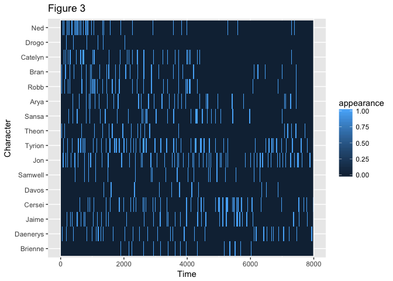

### Character Relationships

Figures 4 and 5 look at which characters appear together and how they are connected to each other. Each row looks at a specific character and their interactions with each of the other characters. Figure 4 shows how often each character appears with the other out of their total number of appearances. While many characters frequently interact, this really highlights the more isolated characters. This is particularly evident with Khal Drogo and Daenerys who seldom interact with any of the characters listed except each other. Figure 5 takes each of these relationships and attempts to analyze it based on the sentiment of the words in the passage. The sentiment is calculated using the AFINN sentiment dictionary which pairs each word in the text with a sentiment score based on its positive or negative implications. This shows the sentiment of each character as well as the sentiment of their relationships with other characters and how that changes from character to character. For example, Bran has a more negative overall sentiment but his relationship with Catelyn is much more positive. For both of these figures there is the shortcoming that some of the characters have fewer total appearances which can cause the data to appear more extreme.

[interactive chart not shown]

These types of visualizations can provide interesting areas of insight in these types of more complex books that would be well augmented with other forms of literary analysis. This type of data-driven literary analysis is very useful in providing a new perspective that can be incorporated into a deeper understanding of the books and the complexities of the plot within. They are most effective when applied to a very specific topic within the book rather than a more comprehensive model, which is part of why they can be so useful in analysis.

## Character Death Prediction